# Final Project: Exploring Gender, Education, and Agriculture in Honduras

Katie Mulder

11/19/2021

```r
##Reading in the data and libraries
library(tidyverse)
library(ghibli)
library(GGally)
library(sf)
library(rnaturalearth)
library(rnaturalearthdata)
library(tigris)
library(patchwork)
world <- ne_countries(scale = "medium", returnclass = "sf")
honduras <- read_csv("data/hnd_ind_clean.csv")
view(honduras)

##Data source: World Bank Group
```

# Introduction

The goal of this project is to understand Honduran agricultural and labor force trends and how these specifically relate to women. The primary question is that over time, are women increasing representation in the agricultural sector? If so, what else is happening in the background that could be affecting women’s rights and representation in the workforce (i.e. with education)?

# Relevant Background

These three graphs work to display general trends for relevant background information. In the graph on the left, it is clear that the percentage of the Honduran population that is living in rural areas is declining over time. In the middle graph, it is clear that the share of exports that are agricultural goods are also falling over time. It is interesting to note that the seemingly premature dip in percentage of agricultural exports at around 1998 was likely caused by Hurricane Mitch, which wiped out a significant portion of Honduran crops. In the rightmost graph, we see that the percentage of the population employed by the agriculture sector has been decreasing over time, which is notable since the share of women in this sector has been increasing over the same period as discussed below.

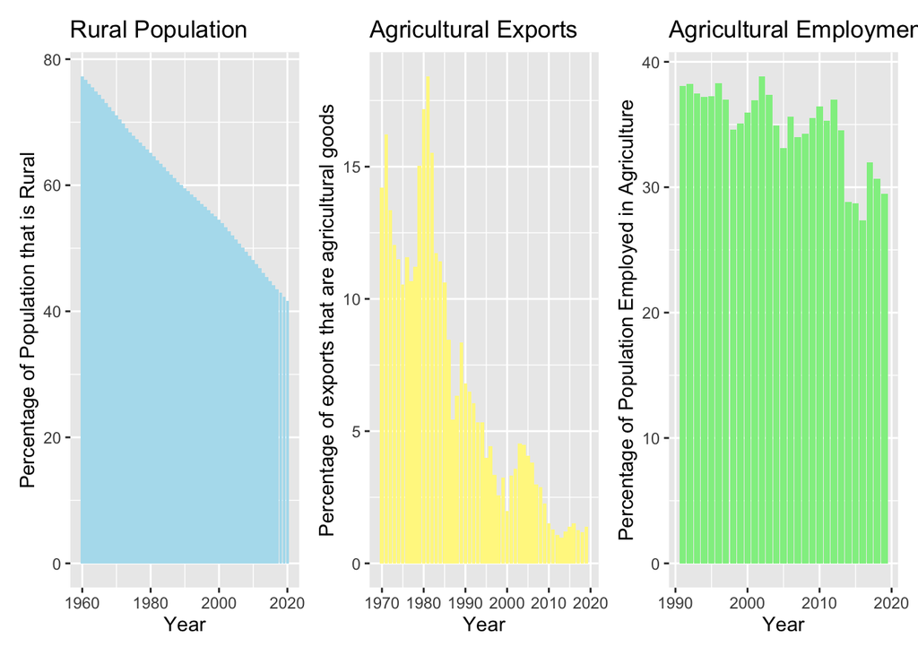

```r
exports_plot <- ggplot(honduras, aes(x = year, y = percent_exports_agricultural))+
geom_bar(stat = "identity", fill = "khaki1")+
labs(x="Year", y="Percentage of exports that are agricultural goods", title="Agricultural Exports")

rural_plot <- ggplot(honduras, aes(x = year, y = rural_percent_population))+
geom_bar(stat = "identity", fill = "lightblue2")+
labs(x="Year", y="Percentage of Population that is Rural", title="Rural Population")

agriculture_plot <- ggplot(honduras, aes(x = year, y = percent_agro_emplpoyment))+
geom_bar(stat = "identity", fill = "palegreen2")+
labs(x="Year", y="Percentage of Population Employed in Agriculture", title="Agricultural Employment")


rural_plot + exports_plot + agriculture_plot
```

# Labor Force Trends

This simple line plot demonstrates that the percentage of the labor force that is made up of women is increasing over time. Although expected, it is interesting to see that the relationship is not linear, and that during certain periods of time there are unexpected decreases. This helps to explain some of the variation in the next plot, as the points are not demonstrating a perfect relationship between women in the agricultural sector and time.

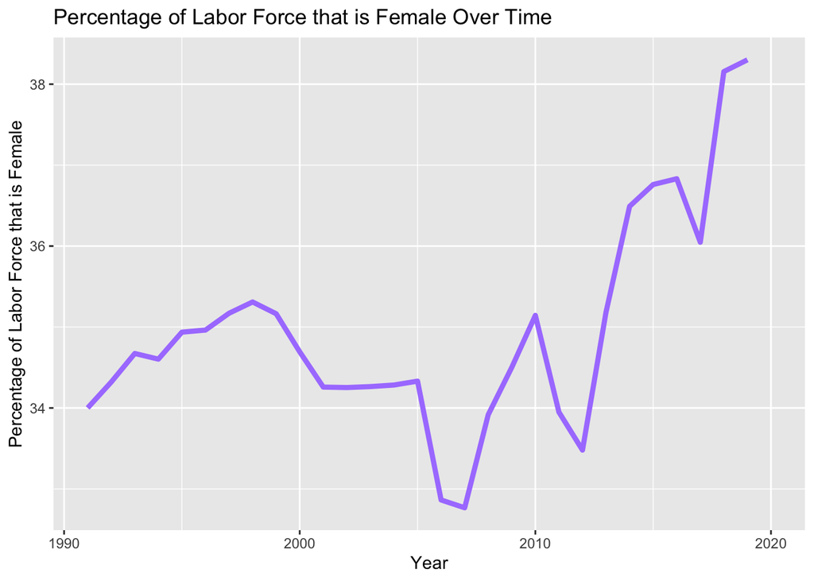

```r
line_plot <- honduras %>%
filter(year>1990)

ggplot(line_plot, aes(x = year, y = percent_laborforce_female)) +
  geom_line(color = "mediumpurple1", size = 1.5) +
  labs(x = "Year", y = "Percentage of Labor Force that is Female",
       title = "Percentage of Labor Force that is Female Over Time")
```

# Women in Agriculture

This scatter plot displays the percentage of female agricultural workers between 1990 and 2020. There is a blue vertical line at 1997, which represents the first year that there were laws in place in Honduras to prevent the harassment of women in the workplace. Similarly at the year 2000, there is a coral vertical line which represents the first year that there were laws in place to prevent gender discrimination in the work place. The size of each point depicts the size of the rural population. Over time, it is clear that as the rural population has become larger and laws that protect women have been put in place, the number of women in the agricultural sector has increased in Honduras. The graph above depicts that the percentage of people living in rural areas is decreasing, which is also interesting to note; women are slowly becoming a larger share of those working in this sector.

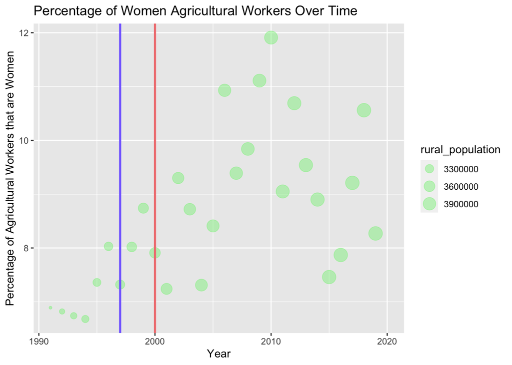

```r
honduras <- honduras%>%
  mutate(workplace_sexual_harassment_legislation = factor(workplace_sexual_harassment_legislation))

harassment_protection_levels <- c("yes", "no")

honduras <- honduras %>%
  mutate(workplace_sexual_harassment_legislation = fct_relevel (workplace_sexual_harassment_legislation, harassment_protection_levels ))

plot_1 <- honduras %>%
filter(year>1990)

 ggplot(plot_1, aes(x = year, y = percent_female_agro_employment, size = rural_population)) +
  geom_point(color = "lightgreen", alpha = 0.5) +
  geom_vline(xintercept = 2000, linetype="solid",
                color = "lightcoral", size=1.0) +
  geom_vline(xintercept = 1997, linetype="solid",
                color = "lightslateblue", size=1.0) +
  labs(x = "Year", y = "Percentage of Agricultural Workers that are Women",
       title = "Percentage of Women Agricultural Workers Over Time")
```

# Education Trends

This graph demonstrates that the number of women with no education is decreasing over time for all age groups. This is the most drastic for the older age groups, such as the early 60s, where in the 1990s, more than 50% of women had no education at all. This ties into the above visualization because it’s interesting to note that while women in Honduras become more educated, they are also becoming more represented in the workforce.

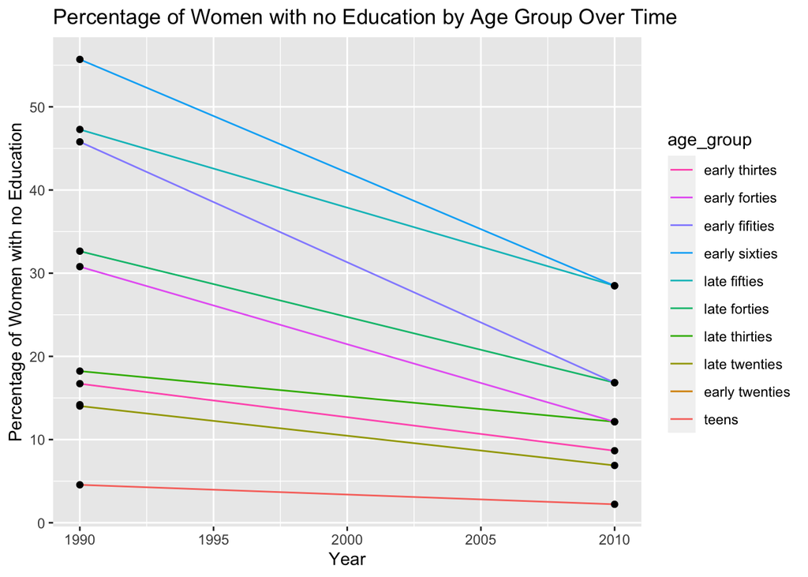

```r
honduras_education <- read_csv("hondy_education.csv")

honduras_education <- honduras_education %>%
  mutate(age_group = factor(age_group))

age_group_levels <- c("teens", "early twenties", "late twenties", "early thirties", "late thirties", "early forites", "late forties", "early fifties", "late fifties", "early sixties")

honduras_education <- honduras_education %>%
  mutate(age_group = fct_relevel (age_group, age_group_levels ))

view(honduras_education)

honduras_education %>%
  filter(year %in% c(1990, 2010)) %>%
  ggplot(aes(x = year, y = percentage_no_ed, fill = age_group)) +
  geom_line(aes(group = age_group, color = age_group)) +
  geom_point() +
  scale_color_discrete(guide = guide_legend(reverse=TRUE)) +
  guides(fill = "none") +
   labs(x = "Year", y = "Percentage of Women with no Education",
       title = "Percentage of Women with no Education by Age Group Over Time")
```

# Summary

In summary, it’s important to note that more rigorous research should be dedicated to understanding these relationships. Looking at various policy interventions and how they might affect a woman’s likelihood to and comfort in joining the workforce should be prioritized.